# Algorithme Tabou

```python
import numpy as np
import matplotlib.pyplot as plt
import time
import copy
```

Nous commençons par définir les paramètres du problème :

- q : Capacité maximale de chaque camion.
- omega : Coût fixe associé à l'utilisation d un camion.

Ensuite, nous définissons deux fonctions essentielles :

- `fitness()` : Évalue la qualité d'une solution (plus le score est bas, meilleure est la solution).
- `compute_distance_matrix()` : Calcule les distances entre tous les points du problème.

```python
q = 40      # Capacité maximale du camion
omega = 50  # Coût fixe par camion utilisé

def fitness(state, solution, distance_matrix):
    """
    Calcule la fonction objectif d'une solution donnée.

    Args:
        state: Dictionnaire contenant les informations du problème
        solution: Liste d'entiers représentant l'ordre de visite des clients
        distance_matrix: Matrice des distances entre les points

    Returns:
        Valeur de la fonction objectif (coût total)
    """
    orders = state["orders"]

    delivered = set()
    capacity = q
    total_distance = 0

    penalty_count = 0  # Compteur de violations de contraintes
    penalty_factor = 1000  # Multiplicateur de pénalité

    trucks = 0

    for i in range(1, len(solution)):
        prev, curr = solution[i-1], solution[i]

        # Vérifier si le chemin existe
        if distance_matrix[prev, curr] == float("inf"):
            penalty_count += 6  # Le chemin n'existe pas

        total_distance += distance_matrix[prev, curr]

        # Si on est chez un client, livrer sa commande
        if curr != 0:
            if capacity < orders[curr]:
                penalty_count += (orders[curr] - capacity + 1) // 2  # Capacité insuffisante

            capacity -= orders[curr]
            delivered.add(curr)

        # Si on est de retour au dépôt, recharger le camion
        if curr == 0:
            trucks += 1
            capacity = q

    # S'assurer que toutes les commandes sont livrées
    if len(delivered) < len(orders) - 1:  # En excluant le dépôt
        penalty_count += 5 * (len(orders) - 1 - len(delivered))  # Certaines commandes n'ont pas été livrées

    # S'assurer que le chemin commence et se termine au dépôt
    if solution[0] != 0 or solution[-1] != 0:
        penalty_count += 2  # La route ne commence/finit pas au dépôt

    # Score final: distance totale + coût des camions + pénalités
    trucks_value = trucks * omega
    penalty_value = penalty_count * penalty_factor
    return total_distance + trucks_value + penalty_value

def compute_distance_matrix(state):
    """
    Calcule la matrice des distances entre tous les points.

    Args:
        state: Dictionnaire contenant les positions des points

    Returns:
        Matrice des distances
    """
    coords = state["position"]
    n = len(coords)

    dist_matrix = np.zeros((n, n))
    for i in range(n):
        for j in range(n):
            dist_matrix[i, j] = np.sqrt((coords[i][0] - coords[j][0])**2 + (coords[i][1] - coords[j][1])**2)
    return dist_matrix
```

Nous allons maintenant définir les fonctions nécessaires pour l'algorithme de recherche tabou :

- `construct_initial_solution()` : Crée une solution initiale valide.
- `count_trucks()` : Compte le nombre de camions utilisés dans une solution.
- `is_valid_solution()` : Vérifie si une solution respecte les contraintes de capacité.
- `tabu_search()` : Implémente l'algorithme de recherche tabou.
- `plot_solution()` : Visualise la solution sur un graphique.
- `plot_cost_evolution()` : Trace l'évolution des coûts pendant la recherche.

```python
def construct_initial_solution():
    """
    Retourne la solution initiale fournie sous forme de liste plate.

    Returns:
        Liste représentant la solution initiale
    """
    return [0, 1, 2, 3, 0, 4, 5, 6, 0, 7, 8, 9, 10, 11, 12, 0]

def count_trucks(solution):
    """
    Compte le nombre de camions utilisés (nombre de retours au dépôt).

    Args:
        solution: Liste représentant une solution

    Returns:
        Nombre de camions utilisés
    """
    return solution.count(0) - 1  # On retire le premier 0 (départ)

def is_valid_solution(solution, orders, capacity):
    """
    Vérifie que chaque camion respecte sa capacité.

    Args:
        solution: Liste représentant une solution
        orders: Liste des commandes des clients
        capacity: Capacité maximale du camion

    Returns:
        Booléen indiquant si la solution est valide
    """
    total_load = 0
    for node in solution:
        if node == 0:  # Retour au dépôt -> Réinitialisation de la charge
            total_load = 0
        else:
            total_load += orders[node]
            if total_load > capacity:
                return False  # Dépassement de la capacité
    return True
```

L'algorithme de recherche tabou est une métaheuristique qui permet d'éviter les optima locaux en interdisant temporairement (mettant "tabou") certains mouvements qui pourraient ramener à des solutions déjà visitées.

Notre implémentation :

1. Commence avec une solution initiale.
2. Explore le voisinage en effectuant des échanges entre les positions des clients.
3. Choisit le meilleur voisin non tabou (ou utilise un critère d'aspiration).
4. Met à jour la liste tabou et continue jusqu'à atteindre le nombre maximum d'itérations.

La taille de la liste **`tabu_list`** varie au cours des itérations, mais elle est principalement contrôlée par le paramètre **`tabu_tenure`**. Voici son évolution :

1. **Ajout d'un mouvement tabou** :
   - Lorsqu'un mouvement `(i, j)` est sélectionné pour une nouvelle solution, il est ajouté à `tabu_list` :

     ```
     tabu_list.append(move)
     ```

2. **Limitation de la taille de la liste tabou** :
   - Si la taille de `tabu_list` dépasse `tabu_tenure`, le plus ancien mouvement est supprimé (stratégie FIFO) :

     ```
     if len(tabu_list) > tabu_tenure:
         tabu_list.pop(0)
     ```

```python
def tabu_search(state, initial_solution, max_iter, tabu_tenure):
    """
    Implémentation de la recherche tabou pour le problème de tournées de véhicules.

    Args:
        state: Dictionnaire contenant les informations du problème
        initial_solution: Solution initiale
        max_iter: Nombre maximum d'itérations
        tabu_tenure: Taille de la liste tabou

    Returns:
        Tuple contenant la meilleure solution trouvée et son coût
    """
    start_time = time.time()  # Début du chronomètre

    distance_matrix = compute_distance_matrix(state)
    best_solution = initial_solution.copy()
    current_solution = initial_solution.copy()
    best_cost = fitness(state, best_solution, distance_matrix)
    current_cost = best_cost
    tabu_list = []

    # Pour suivre l'évolution de la recherche
    iteration_costs = []
    best_costs = []

    for iteration in range(max_iter):
        neighborhood = []

        # Générer des voisins avec des swaps
        for i in range(1, len(current_solution) - 1):  # Ignorer le dépôt (0)
            for j in range(i+1, len(current_solution) - 1):
                if i != j:
                    new_solution = current_solution.copy()
                    new_solution[i], new_solution[j] = new_solution[j], new_solution[i]

                    if is_valid_solution(new_solution, state['orders'], q):
                        cost = fitness(state, new_solution, distance_matrix)
                        move = (i, j)
                        neighborhood.append((new_solution, cost, move))

        if not neighborhood:
            print(f"Itération {iteration}: Aucun voisin valide trouvé, arrêt de la recherche.")
            break  # Si aucun voisin n'est valide, on arrête

        # Trier les voisins par coût
        neighborhood.sort(key=lambda x: x[1])

        # Sélectionner le meilleur voisin non tabou (ou le meilleur voisin si aspiration)
        found_better = False
        for candidate, cost, move in neighborhood:
            if move not in tabu_list or cost < best_cost:  # Critère d'aspiration
                current_solution = candidate.copy()
                current_cost = cost

                if move not in tabu_list:
                    tabu_list.append(move)
                    if len(tabu_list) > tabu_tenure:
                        tabu_list.pop(0)

                if cost < best_cost:
                    best_solution = candidate.copy()
                    best_cost = cost

                found_better = True
                break

        if not found_better:
            # Si tous les mouvements sont tabou, on choisit le meilleur quand même
            candidate, cost, move = neighborhood[0]
            current_solution = candidate.copy()
            current_cost = cost
            tabu_list.append(move)
            if len(tabu_list) > tabu_tenure:
                tabu_list.pop(0)

        # Enregistrer les coûts pour l'analyse
        iteration_costs.append(current_cost)
        best_costs.append(best_cost)



    end_time = time.time()  # Fin du chronomètre
    execution_time = end_time - start_time


    # Retourner la meilleure solution, son coût, et les données d'analyse
    return best_solution, best_cost, iteration_costs, best_costs, execution_time
```

Les suivante fonctions nous permettent de :

1. Visualiser les routes sur une carte 2D.
2. Tracer l'évolution des coûts pendant la recherche tabou.

```python
def plot_solution(state, solution, title=""):
    """
    Visualise la solution sur un graphique.

    Args:
        state: Dictionnaire contenant les positions des points
        solution: Liste représentant une solution
        title: Titre du graphique
    """
    positions = state["position"]
    depot = positions[0]
    clients = positions[1:]

    plt.figure(figsize=(10, 6))
    plt.scatter(*depot, c='red', marker='s', s=100, label='Dépôt')
    for i, (x, y) in enumerate(clients, start=1):
        plt.scatter(x, y, c='blue', s=50)
        plt.text(x, y, f"{i}\n(q={state['orders'][i]})", fontsize=9, verticalalignment='bottom', horizontalalignment='right')

    colors = ['g', 'b', 'm', 'c', 'y', 'orange', 'purple']
    truck_count = 0
    current_color = colors[truck_count % len(colors)]

    for i in range(len(solution) - 1):
        start, end = solution[i], solution[i + 1]
        if start == 0 and end != 0:  # Nouveau camion qui quitte le dépôt
            truck_count += 1
            current_color = colors[(truck_count-1) % len(colors)]
            plt.plot([positions[start][0], positions[end][0]],
                    [positions[start][1], positions[end][1]],
                    color=current_color, linewidth=2, marker='o',
                    label=f'Camion {truck_count}')
        else:
            plt.plot([positions[start][0], positions[end][0]],
                    [positions[start][1], positions[end][1]],
                    color=current_color, linewidth=2, marker='o')

    plt.legend()
    plt.grid(True, linestyle='--', alpha=0.7)
    plt.title(f"{title} - Nombre de camions : {truck_count}")
    plt.xlabel("Coordonnée X")
    plt.ylabel("Coordonnée Y")
    plt.show()

def plot_cost_evolution_interation(iteration_costs, best_costs):
    """
    Trace l'évolution des coûts au cours des itérations.

    Args:
        iteration_costs: Liste des coûts à chaque itération
        best_costs: Liste des meilleurs coûts à chaque itération
    """
    plt.figure(figsize=(12, 6))
    plt.plot(iteration_costs, 'b', alpha=0.5, label='Coût courant')
    plt.plot(best_costs, 'r-', linewidth=2, label='Meilleur coût')
    plt.xlabel('Itération')
    plt.ylabel('Coût')
    plt.title('Évolution du coût pendant la recherche tabou')
    plt.legend()
    plt.grid(True)
    plt.show()

def plot_cost_evolution_longueur(Longueurs, best_costs):
    """
    Trace l'évolution des coûts pour différentes longueur de list tabou.

    """
    if len(Longueurs) != len(best_costs):
        raise ValueError("Les listes Longueurs et coût doivent avoir la même longueur.")

    plt.plot(Longueurs,best_costs, 'r',markersize=8, label='Meilleur coût')
    plt.xlabel('Longueur')
    plt.ylabel('Coût')
    plt.title('Évolution du coût avec la longueur de la liste tabou')
    plt.legend()
    plt.grid(True)
    plt.show()



def plot_time_longueur(Longueurs, temps):
    """
    Trace l'évolution du temps de calcul pour différentes longueurs de la liste tabou.

    Paramètres :
    - Longueurs : Liste des tailles de la liste tabou testées.
    - temps : Liste des temps de calcul correspondants.

    """
    if len(Longueurs) != len(temps):
        raise ValueError("Les listes Longueurs et temps doivent avoir la même longueur.")

    plt.figure(figsize=(12, 6))
    plt.plot(Longueurs, temps, 'bo-', linewidth=2, markersize=6, label="Temps de calcul")

    plt.xlabel("Longueur de la liste tabou")
    plt.ylabel("Temps d'exécution (s)")
    plt.title("Évolution du temps de calcul avec la longueur de la liste tabou")

    plt.legend()
    plt.grid(True)
    plt.show()
```

Nous définissons maintenant l'état initial du problème :

- Les positions des clients et du dépôt.
- Les quantités commandées par chaque client.

Nous calculons également la matrice des distances entre tous les points.

```python
# Définition de l'état initial du problème
state = {
    "position": [
        (0, 0),  # Dépôt
        (5, 2), (3, -3), (2, 2), (1, 0),  # Clients 1-4
        (3, 3), (2, 1), (-5, 0), (7, 1),  # Clients 5-8
        (-3, -2), (5, 1), (1, 2), (4, 2)  # Clients 9-12
    ],
    "orders": [0, 5, 10, 7, 8, 6, 9, 4, 3, 1, 2, 3, 7]  # Commandes: 0 pour le dépôt, valeurs pour les clients
}

# Calcul de la matrice des distances
distance_matrix = compute_distance_matrix(state)
# -
```

Avant d'appliquer la recherche tabou, nous évaluons la qualité de la solution initiale.

```
Solution initiale: [0, 1, 2, 3, 0, 4, 5, 6, 0, 7, 8, 9, 10, 11, 12, 0]
Nombre de camions dans la solution initiale: 3
Coût de la solution initiale: 225.39660989670918
```

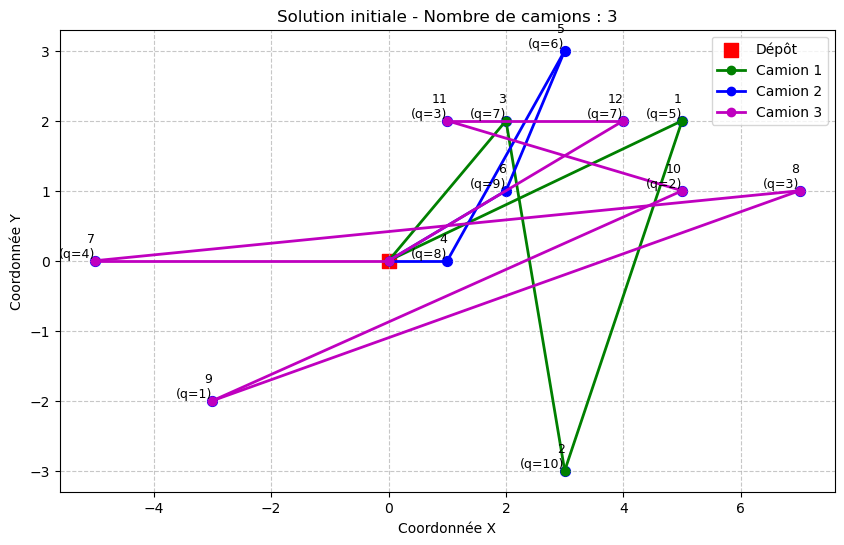

```python
# Création de la solution initiale
initial_solution = construct_initial_solution()

# Calcul du coût de la solution initiale
initial_cost = fitness(state, initial_solution, distance_matrix)
initial_trucks = count_trucks(initial_solution)

print(f"Solution initiale: {initial_solution}")
print(f"Nombre de camions dans la solution initiale: {initial_trucks}")
print(f"Coût de la solution initiale: {initial_cost}")

# Visualisation de la solution initiale
plot_solution(state, initial_solution, "Solution initiale")
```

Nous allons maintenant appliquer l'algorithme de recherche tabou pour améliorer la solution initiale.

```python
# Lancement de la recherche tabou
optimized_solution, min_cost, iter_costs, best_costs, exec_time = tabu_search(
    state, initial_solution, max_iter=100, tabu_tenure=10
)

# Affichage des résultats
print("\nRésultats de l'optimisation:")
print(f"Solution optimisée: {optimized_solution}")
nbr_trucks = count_trucks(optimized_solution)
print(f"Nombre de camions utilisés: {nbr_trucks}")
print(f"Coût optimisé: {min_cost}")
print(f"Temps d'exécution: {exec_time:.2f} secondes")

# Pourcentage d'amélioration
improvement = ((initial_cost - min_cost) / initial_cost) * 100
print(f"Pourcentage d'amélioration: {improvement:.2f}%")
```

```
Résultats de l'optimisation:
Solution optimisée: [0, 0, 9, 7, 11, 6, 4, 0, 3, 5, 12, 1, 10, 8, 2, 0]
Nombre de camions utilisés: 3
Coût optimisé: 186.14331003139716
Temps d'exécution: 0.09 secondes
Pourcentage d'amélioration: 17.42%
```

Examinons visuellement la solution trouvée par l'algorithme de recherche tabou.

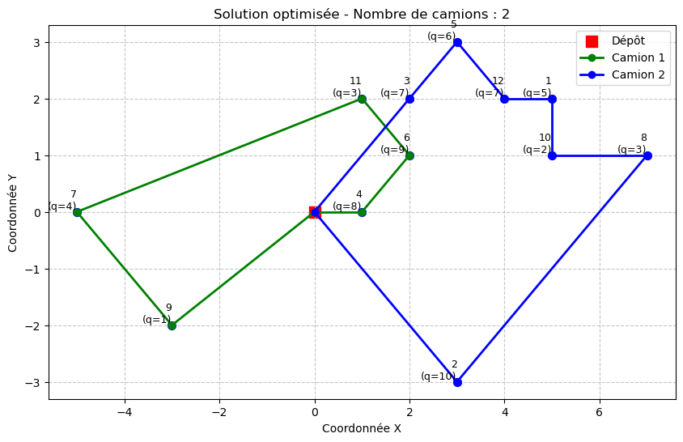

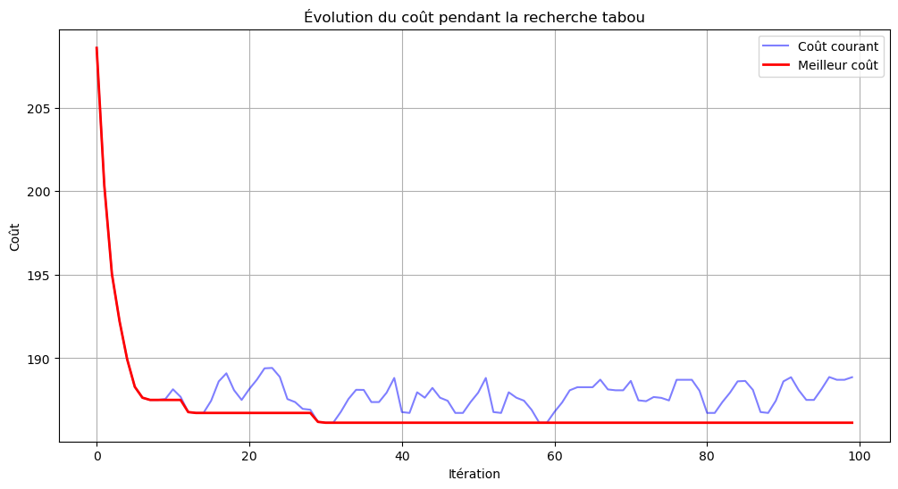

```python
# Visualisation de la solution optimisée
plot_solution(state, optimized_solution, "Solution optimisée")

# Visualisation de l'évolution des coûts
plot_cost_evolution(iter_costs, best_costs)
```

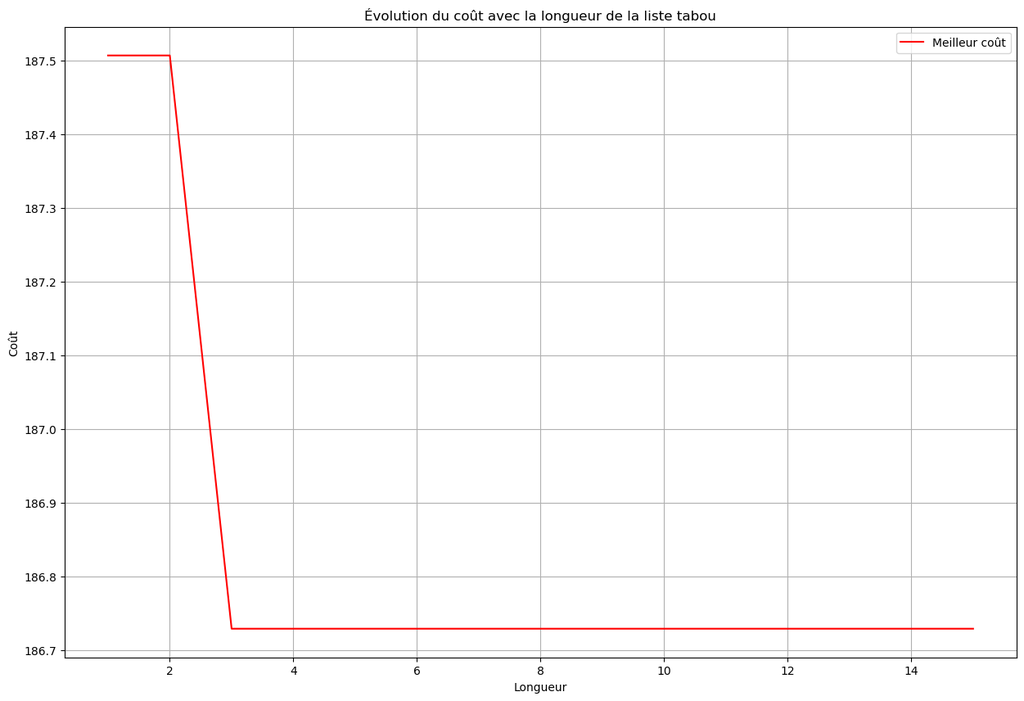

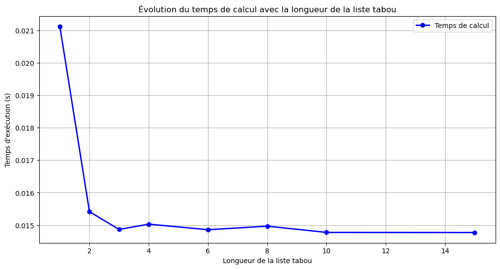

```python
# Définition des différentes longueurs d'itération à tester
lenght_to_test = [1, 2,3, 4, 6, 8,10,15]
results = []

Temps=[]
Opt_cost=[]

plt.figure(figsize=(15, 10))

for lenght in lenght_to_test:


    # Copie de la solution initiale pour garantir le même point de départ
    test_solution = initial_solution.copy()

    # Exécution de la recherche tabou
    opt_solution, opt_cost, _, best_costs, exec_time = tabu_search(
        state, test_solution, max_iter=20, tabu_tenure=lenght
    )

    Temps.append(exec_time)
    Opt_cost.append(opt_cost)



# Tracer l'évolution du coût
plot_cost_evolution_longueur(lenght_to_test, Opt_cost)


# Tracer l'évolution temps
plot_time_longueur(lenght_to_test, Temps)
```